# Week 6 - Simulation Project

STAT 420, Summer 2020, D. Unger

# Directions

This is an **individual** project. This is NOT like a homework assignment. This is NOT an assignment where collaboration is permissible. Discussion of question intent, coding problems/issues, and project administration may be discussed on the message board on a limited basis. However, sharing, copying, or providing any part of this project to another student is an infraction of the University’s rules on academic integrity. Any violation will be punished as severely as possible.

- Your project must be submitted through Coursera. You are required to upload one `.zip` file, named `yourNetID-sim-proj.zip`, which contains:
  - Your RMarkdown file which should be saved as `yourNetID-sim-proj.Rmd`.
  - The result of knitting your RMarkdown file as `yourNetID-sim-proj.html`.
  - Any outside data provided as a `.csv` file. (In this case, `study_1.csv` and `study_2.csv`.)
- Your `.Rmd` file should be written such that, when stored in a folder with any data you are asked to import, it will knit properly without modification. If your `.zip` file is organized properly, this should not be an issue.
- Include your name and NetID in the final document, not only in your filenames.

This project consists of **three** simulation studies. Unlike a homework assignment, these “exercises” are not broken down into parts (e.g., a, b, c), and so your analysis will not be similarly partitioned. Instead, your document should be organized more like a true project report, and it should use the overall format:

- Simulation Study 1
- Simulation Study 2
- Simulation Study 3

Within each of the simulation studies, you should use the format:

- Introduction
- Methods
- Results
- Discussion

The **introduction** section should relay what you are attempting to accomplish. It should provide enough background to your work such that a reader would not need this directions document to understand what you are doing. (Basically, assume the reader is mostly familiar with the concepts from the course, but not this project.)

The **methods** section should contain the majority of your “work.” This section will contain the bulk of the `R` code that is used to generate the results. Your `R` code is not expected to be perfect idiomatic `R`, but it is expected to be understood by a reader without too much effort. Use RMarkdown and code comments to your advantage to explain your code if needed.

The **results** section should contain numerical or graphical summaries of your results as they pertain to the goal of each study.

The **discussion** section should contain discussion of your results. The discussion section should contain discussion of your results. Potential topics for discussion are suggested at the end of each simulation study section, but they are not meant to be an exhaustive list. These simulation studies are meant to be explorations into the principles of statistical modeling, so do not limit your responses to short, closed form answers as you do in homework assignments. Use the potential discussion questions as a starting point for your response.

- Your resulting `.html` file will be considered a self-contained “report,” which is the material that will determine the majority of your grade. Be sure to visibly include all `R` code and output that is *relevant*. (You should not include irrelevant code you tried that resulted in error or did not answer the question correctly.)
- Grading will be based on a combination of completing the required tasks, discussion of results, `R` usage, RMarkdown usage, and neatness and organization. For full details see the provided rubric.
- At the beginning of *each* of the three simulation studies, set a seed equal to your birthday, as is done on homework. (It should be the first code run for each study.) These should be the only three times you set a seed.

```r
birthday = 18760613
set.seed(birthday)
```

# Simulation Study 1: Significance of Regression

In this simulation study we will investigate the significance of regression test. We will simulate from two different models:

1. The **“significant”** model

$$Y_i = \beta_0 + \beta_1 x_{i1} + \beta_2 x_{i2} + \beta_3 x_{i3} + \epsilon_i$$

where $\epsilon_i \sim N(0, \sigma^2)$ and

- $\beta_0 = 3$,
- $\beta_1 = 1$,
- $\beta_2 = 1$,
- $\beta_3 = 1$.
2. The **“non-significant”** model

$$Y_i = \beta_0 + \beta_1 x_{i1} + \beta_2 x_{i2} + \beta_3 x_{i3} + \epsilon_i$$

where $\epsilon_i \sim N(0, \sigma^2)$ and

- $\beta_0 = 3$,
- $\beta_1 = 0$,
- $\beta_2 = 0$,
- $\beta_3 = 0$.

For both, we will consider a sample size of $25$ and three possible levels of noise. That is, three values of $\sigma$.

- $n = 25$
- $\sigma \in (1, 5, 10)$

Use simulation to obtain an empirical distribution for each of the following values, for each of the three values of $\sigma$, for both models.

- The **$F$ statistic** for the significance of regression test.
- The **p-value** for the significance of regression test
- **$R^2$**

For each model and $\sigma$ combination, use $2000$ simulations. For each simulation, fit a regression model of the same form used to perform the simulation.

Use the data found in `study_1.csv` for the values of the predictors. These should be kept constant for the entirety of this study. The `y` values in this data are a blank placeholder.

Done correctly, you will have simulated the `y` vector $2 (models)×3 (sigmas)×2000 (sims)=12000$ times.

Potential discussions:

- Do we know the true distribution of any of these values?
- How do the empirical distributions from the simulations compare to the true distributions? (You could consider adding a curve for the true distributions if you know them.)
- How are each of the $F$ statistic, the p-value, and $R^2$ related to $\sigma$? Are any of those relationships the same for the significant and non-significant models?

Additional things to consider:

- Organize the plots in a grid for easy comparison.

$\underline{Introduction}$

This is the part i explain what i did. We need to consider two models, “significant” model and “non-significant model”. Difference being that $\beta_1$, $\beta_2$, $\beta_3$ are zero in the later.

The Generic Linear equation being
$$Y_i = \beta_0 + \beta_1 x_{i1} + \beta_2 x_{i2} + \beta_3 x_{i3} + \epsilon_i$$

**“Significant Model”**
$$Y_i = \beta_0 + \beta_1 x_{i1} + \beta_2 x_{i2} + \beta_3 x_{i3} + \epsilon_i$$

**“Non-Significant Model”**
$$Y_i = \beta_0 + \epsilon_i$$

We create y_values from the Linear equations based on the above equations and apply linear model and calculate the **“F-Statistics”**, **“P-Value”** and **“R2”**

$\underline{Method}$

Below we calculate the F-statistic, P-Value and R2 for **Significant model** with the help of broom library.

```r
library(broom)

#Significance Test
# sigma = 1, 5, 10
# Calculate F Statistic, p-value and R2

beta_0 = 3
beta_1 = 1
beta_2 = 1
beta_3 = 1

n = 25 #sample_size
study1 = read.csv("study_1.csv")
x1 = study1$x1
x2 = study1$x2
x3 = study1$x3
x0 = rep(1, n)
sig = 1 #1, 5, 10

X = cbind(x0, x1, x2, x3)
C = solve(t(X) %*% X)
y = rep(0, n)

sig = 1
num_sims = 2 # RAJA FIXME
sim_data = data.frame(y, x1, x2, x3)
f_stat_1 = rep(0, num_sims)
p_val_1 = rep(0, num_sims)
r2_1 = rep(0, num_sims)
for (i in 1:num_sims) {
 eps = rnorm(25, mean = 0, sd = sig)
 sim_data$y = beta_0 * x0 + beta_1 * x1 + beta_2 * x2 + beta_3 * x3 + eps
 sim_data_lm = lm(y ~ x1 + x2 + x3, data = sim_data)

 f_stat_1[i] = glance(sim_data_lm)$statistic
 p_val_1[i] = glance(sim_data_lm)$p.value
 r2_1[i] = glance(sim_data_lm)$r.squared
}

sig = 5
f_stat_5 = rep(0, num_sims)
p_val_5 = rep(0, num_sims)
r2_5 = rep(0, num_sims)
for (i in 1:num_sims) {
 eps = rnorm(25, mean = 0, sd = sig)
 sim_data$y = beta_0 * x0 + beta_1 * x1 + beta_2 * x2 + beta_3 * x3 + eps
 sim_data_lm = lm(y ~ x1 + x2 + x3, data = sim_data)

 f_stat_5[i] = glance(sim_data_lm)$statistic
 p_val_5[i] = glance(sim_data_lm)$p.value
 r2_5[i] = glance(sim_data_lm)$r.squared
}

sig = 10
f_stat_10 = rep(0, num_sims)
p_val_10 = rep(0, num_sims)
r2_10 = rep(0, num_sims)
for (i in 1:num_sims) {
 eps = rnorm(25, mean = 0, sd = sig)
 sim_data$y = beta_0 * x0 + beta_1 * x1 + beta_2 * x2 + beta_3 * x3 + eps
 sim_data_lm = lm(y ~ x1 + x2 + x3, data = sim_data)

 f_stat_10[i] = glance(sim_data_lm)$statistic
 p_val_10[i] = glance(sim_data_lm)$p.value
 r2_10[i] = glance(sim_data_lm)$r.squared
}
```

Below we calculate the F-statistic, P-Value and R2 for **Non-Significant model** with the help of broom library.

```r
#Non-Significance Test
beta_0 = 3
beta_1 = 0
beta_2 = 0
beta_3 = 0

n = 25 #sample_size
study1 = read.csv("study_1.csv")
x1 = study1$x1
x2 = study1$x2
x3 = study1$x3
x0 = rep(1, n)
sig = 1 #1, 5, 10

X = cbind(x0, x1, x2, x3)
C = solve(t(X) %*% X)
y = rep(0, n)

sig = 1
f_stat_ns_1 = rep(0, num_sims)
p_val_ns_1 = rep(0, num_sims)
r2_ns_1 = rep(0, num_sims)
for (i in 1:num_sims) {
 eps = rnorm(25, mean = 0, sd = sig)
 sim_data$y = beta_0 * x0 + beta_1 * x1 + beta_2 * x2 + beta_3 * x3 + eps
   sim_data_lm = lm(y ~ x1 + x2 + x3, data = sim_data)

 f_stat_ns_1[i] = glance(sim_data_lm)$statistic
 p_val_ns_1[i] = glance(sim_data_lm)$p.value
 r2_ns_1[i] = glance(sim_data_lm)$r.squared
}

sig = 5
f_stat_ns_5 = rep(0, num_sims)
p_val_ns_5 = rep(0, num_sims)
r2_ns_5 = rep(0, num_sims)
for (i in 1:num_sims) {
 eps = rnorm(25, mean = 0, sd = sig)
 sim_data$y = beta_0 * x0 + beta_1 * x1 + beta_2 * x2 + beta_3 * x3 + eps
 sim_data_lm = lm(y ~ x1 + x2 + x3, data = sim_data)

 f_stat_ns_5[i] = glance(sim_data_lm)$statistic
 p_val_ns_5[i] = glance(sim_data_lm)$p.value
 r2_ns_5[i] = glance(sim_data_lm)$r.squared
}

sig = 10
f_stat_ns_10 = rep(0, num_sims)
p_val_ns_10 = rep(0, num_sims)
r2_ns_10 = rep(0, num_sims)
for (i in 1:num_sims) {
 eps = rnorm(25, mean = 0, sd = sig)
 sim_data$y = beta_0 * x0 + beta_1 * x1 + beta_2 * x2 + beta_3 * x3 + eps
 sim_data_lm = lm(y ~ x1 + x2 + x3, data = sim_data)

 f_stat_ns_10[i] = glance(sim_data_lm)$statistic
 p_val_ns_10[i] = glance(sim_data_lm)$p.value
 r2_ns_10[i] = glance(sim_data_lm)$r.squared
}
```

$\underline{Results}$

We plot the histograms of f-statistic, p-value and R2 for Significant Model below.

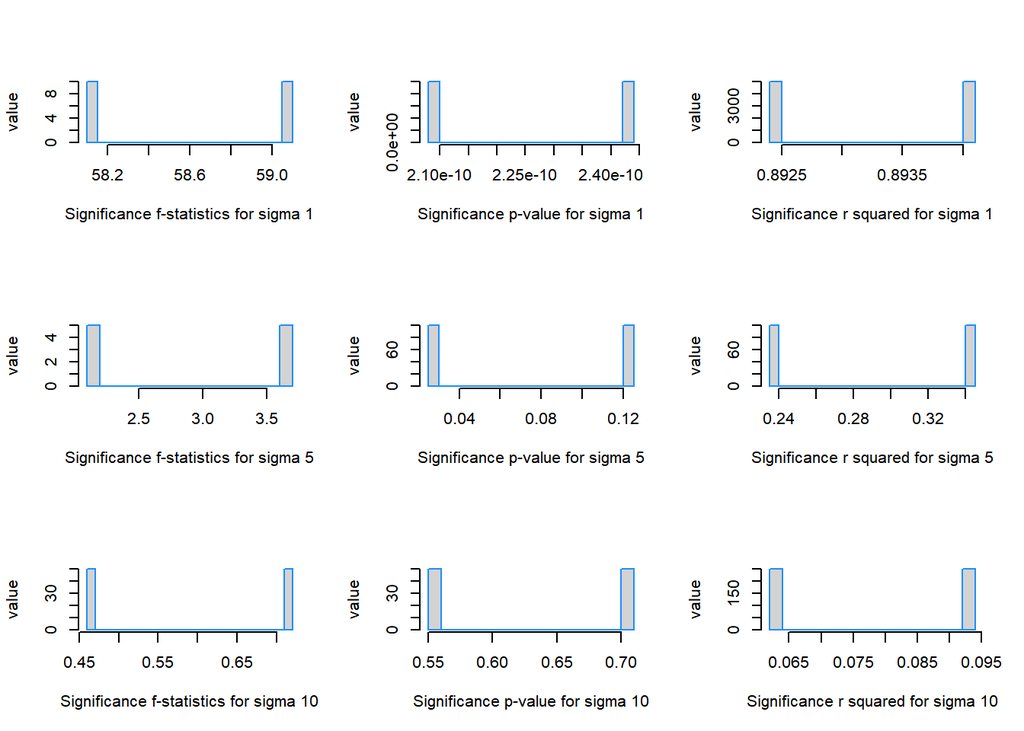

```r
#Plotting significance Model
par(mfrow=c(3,3))

hist(f_stat_1, prob = TRUE, breaks = 20, xlab = "Significance f-statistics for sigma 1", ylab = "value", main = "", border = "dodgerblue")
hist(p_val_1, prob = TRUE, breaks = 20, xlab = "Significance p-value for sigma 1", ylab = "value", main = "", border = "dodgerblue")
hist(r2_1, prob = TRUE, breaks = 20, xlab = "Significance r squared for sigma 1", ylab = "value", main = "", border = "dodgerblue")


hist(f_stat_5, prob = TRUE, breaks = 20, xlab = "Significance f-statistics for sigma 5", ylab = "value", main = "", border = "dodgerblue")
hist(p_val_5, prob = TRUE, breaks = 20, xlab = "Significance p-value for sigma 5", ylab = "value", main = "", border = "dodgerblue")
hist(r2_5, prob = TRUE, breaks = 20, xlab = "Significance r squared for sigma 5", ylab = "value", main = "", border = "dodgerblue")


hist(f_stat_10, prob = TRUE, breaks = 20, xlab = "Significance f-statistics for sigma 10", ylab = "value", main = "", border = "dodgerblue")
hist(p_val_10, prob = TRUE, breaks = 20, xlab = "Significance p-value for sigma 10", ylab = "value", main = "", border = "dodgerblue")
hist(r2_10, prob = TRUE, breaks = 20, xlab = "Significance r squared for sigma 10", ylab = "value", main = "", border = "dodgerblue")
```

We plot the histograms of f-statistic, p-value and R2 for Non-Significant Model below along with the curves for the distributions for comparison.

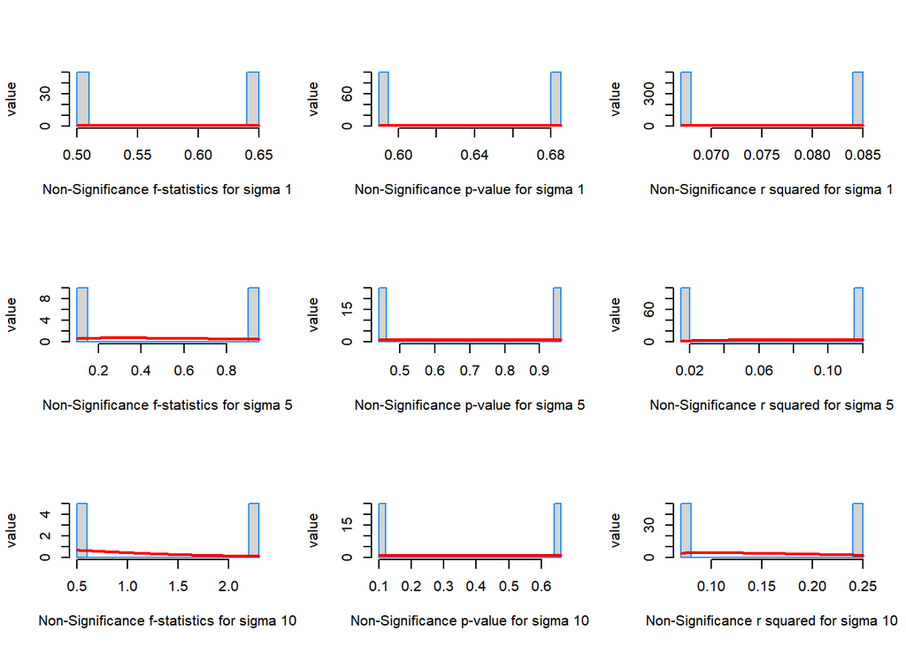

```r
#Plotting Non-significance Model
par(mfrow=c(3,3))

hist(f_stat_ns_1, prob = TRUE, breaks = 20, xlab = "Non-Significance f-statistics for sigma 1", ylab = "value", main = "", border = "dodgerblue")
curve(df(x, df1 = 4 - 1, df2 = 25 - 4), col = "red", add = TRUE, lwd = 2)
hist(p_val_ns_1, prob = TRUE, breaks = 20, xlab = "Non-Significance p-value for sigma 1", ylab = "value", main = "", border = "dodgerblue")
curve(dunif(x), col = "red", add = TRUE, lwd = 2)
hist(r2_ns_1, prob = TRUE, breaks = 20, xlab = "Non-Significance r squared for sigma 1", ylab = "value", main = "", border = "dodgerblue")
curve(dbeta(x, 4/2, (n-4-1)/2),  col = "red", add = TRUE, lwd = 2) # n = 25, p = 4

hist(f_stat_ns_5, prob = TRUE, breaks = 20, xlab = "Non-Significance f-statistics for sigma 5", ylab = "value", main = "", border = "dodgerblue")
curve(df(x, df1 = 4 - 1, df2 = 25 - 4), col = "red", add = TRUE, lwd = 2)
hist(p_val_ns_5, prob = TRUE, breaks = 20, xlab = "Non-Significance p-value for sigma 5", ylab = "value", main = "", border = "dodgerblue")
curve(dunif(x), col = "red", add = TRUE, lwd = 2)
hist(r2_ns_5, prob = TRUE, breaks = 20, xlab = "Non-Significance r squared for sigma 5", ylab = "value", main = "", border = "dodgerblue")
curve(dbeta(x, 4/2, (n-4-1)/2),  col = "red", add = TRUE, lwd = 2) # n = 25, p = 4

hist(f_stat_ns_10, prob = TRUE, breaks = 20, xlab = "Non-Significance f-statistics for sigma 10", ylab = "value", main = "", border = "dodgerblue")
curve(df(x, df1 = 4 - 1, df2 = 25 - 4), col = "red", add = TRUE, lwd = 2)
hist(p_val_ns_10, prob = TRUE, breaks = 20, xlab = "Non-Significance p-value for sigma 10", ylab = "value", main = "", border = "dodgerblue")
curve(dunif(x), col = "red", add = TRUE, lwd = 2)
hist(r2_ns_10, prob = TRUE, breaks = 20, xlab = "Non-Significance r squared for sigma 10", ylab = "value", main = "", border = "dodgerblue")
curve(dbeta(x, 4/2, (n-4-1)/2),  col = "red", add = TRUE, lwd = 2) # n = 25, p = 4
```

$\underline{Discussion}$

**P-Value** Significant model a. P-Value follows a right skew distribution wit the increase of noise in the model. With a sigma value of 1, the p-value distribution is close to the mean value. b. We don’t need to add true distribution curve. c. we notice that the p-value increases with the increase in the sigma value. Meaning that it values are getting distributed away from the mean, resulting is not so reliable estimations.

# Simulation Study 2: Using RMSE for Selection?

In homework we saw how Test RMSE can be used to select the “best” model. In this simulation study we will investigate how well this procedure works. Since splitting the data is random, we don’t expect it to work correctly each time. We could get unlucky. But averaged over many attempts, we should expect it to select the appropriate model.

We will simulate from the model

$$Y_i = \beta_0 + \beta_1 x_{i1} + \beta_2 x_{i2} + \beta_3 x_{i3} + \beta_4 x_{i4} + \beta_5 x_{i5} + \beta_6 x_{i6} + \epsilon_i$$

where $\epsilon_i \sim N(0, \sigma^2)$ and

- $\beta_0 = 0$,
- $\beta_1 = 3$,
- $\beta_2 = -4$,
- $\beta_3 = 1.6$,
- $\beta_4 = -1.1$,
- $\beta_5 = 0.7$,
- $\beta_6 = 0.5$.

We will consider a sample size of $500$ and three possible levels of noise. That is, three values of $\sigma$.

- $n = 500$
- $\sigma \in (1, 2, 4)$

Use the data found in `study_2.csv` for the values of the predictors. These should be kept constant for the entirety of this study. The `y` values in this data are a blank placeholder.

Each time you simulate the data, randomly split the data into train and test sets of equal sizes (250 observations for training, 250 observations for testing).

For each, fit **nine** models, with forms:

- `y ~ x1`
- `y ~ x1 + x2`
- `y ~ x1 + x2 + x3`
- `y ~ x1 + x2 + x3 + x4`
- `y ~ x1 + x2 + x3 + x4 + x5`
- `y ~ x1 + x2 + x3 + x4 + x5 + x6`, the correct form of the model as noted above
- `y ~ x1 + x2 + x3 + x4 + x5 + x6 + x7`
- `y ~ x1 + x2 + x3 + x4 + x5 + x6 + x7 + x8`
- `y ~ x1 + x2 + x3 + x4 + x5 + x6 + x7 + x8 + x9`

For each model, calculate Train and Test RMSE.

$$\text{RMSE}(\text{model, data}) = \sqrt{\frac{1}{n} \sum_{i = 1}^{n}(y_i - \hat{y}_i)^2}$$

Repeat this process with $1000$ simulations for each of the $3$ values of $\sigma$. For each value of $\sigma$, create a plot that shows how average Train RMSE and average Test RMSE changes as a function of model size. Also show the number of times the model of each size was chosen for each value of $\sigma$.

Done correctly, you will have simulated the $y$ vector $3×1000=3000$ times. You will have fit $9×3×1000=27000$ models. A minimal result would use $3$ plots. Additional plots may also be useful.

Potential discussions:

- Does the method **always** select the correct model? On average, does is select the correct model?
- How does the level of noise affect the results?

$\underline{Introduction}$

In this simulation study we look at the RSME calculations based on
$$\text{RMSE}(\text{model, data}) = \sqrt{\frac{1}{n} \sum_{i = 1}^{n}(y_i - \hat{y}_i)^2}$$
for a Train dataset and Test dataset extracted from the given dataset.

$\underline{Method}$

We use broom library to create the summary details of the a LM model.

```r
library(broom)
birthday = 18760613
set.seed(birthday)

rmse = function(acutual, predicted) {
  sqrt(mean((acutual - predicted)^2))
}

beta0 = 0
beta1 = 3
beta2 = -4
beta3 = 1.6
beta4 = -1.1
beta5 = 0.7
beta6 = 0.5

n = 500
study2 = read.csv("study_2.csv")
x0 = rep(1, n)
x1 = study2$x1
x2 = study2$x2
x3 = study2$x3
x4 = study2$x4
x5 = study2$x5
x6 = study2$x6
x7 = study2$x7
x8 = study2$x8
x9 = study2$x9
C = cbind(x0, x1, x2, x3, x4, x5, x6, x7, x8, x9)

sig = 1

sigmas = c(1,2,4)

avg_rmse_train = matrix(0, nrow=3, ncol=9)
avg_rmse_tst = matrix(1, nrow=3, ncol=9)

for (s in 1:length(sigmas)) {

  eps = rnorm(n, mean = 0, sd = sigmas[s])
  study2$y = beta0 * x0 + beta1 * x1 + beta2 * x2 + beta3 * x3 + beta4 * x4 + beta5 * x5 + beta6 * x6 + eps

  num_sims = 3 #1000 RAJA FIXME

  rmse_train_1 = rep(0, num_sims)
  rmse_train_2 = rep(0, num_sims)
  rmse_train_3 = rep(0, num_sims)
  rmse_train_4 = rep(0, num_sims)
  rmse_train_5 = rep(0, num_sims)
  rmse_train_6 = rep(0, num_sims)
  rmse_train_7 = rep(0, num_sims)
  rmse_train_8 = rep(0, num_sims)
  rmse_train_9 = rep(0, num_sims)
  rmse_tst_1 = rep(0, num_sims)
  rmse_tst_2 = rep(0, num_sims)
  rmse_tst_3 = rep(0, num_sims)
  rmse_tst_4 = rep(0, num_sims)
  rmse_tst_5 = rep(0, num_sims)
  rmse_tst_6 = rep(0, num_sims)
  rmse_tst_7 = rep(0, num_sims)
  rmse_tst_8 = rep(0, num_sims)
  rmse_tst_9 = rep(0, num_sims)

  for (i in 1:num_sims) {
    train_idx = sample(1:nrow(study2), 250)
    train_study2 = study2[train_idx, ]
    test_study2 = study2[-train_idx, ]

    model1 = lm(y ~ x1, data = train_study2)
    model2 = lm(y ~ x1 + x2, data = train_study2)
    model3 = lm(y ~ x1 + x2 + x3, data = train_study2)
    model4 = lm(y ~ x1 + x2 + x3 + x4, data = train_study2)
    model5 = lm(y ~ x1 + x2 + x3 + x4 + x5, data = train_study2)
    model6 = lm(y ~ x1 + x2 + x3 + x4 + x5 + x6, data = train_study2)
    model7 = lm(y ~ x1 + x2 + x3 + x4 + x5 + x6 + x7, data = train_study2)
    model8 = lm(y ~ x1 + x2 + x3 + x4 + x5 + x6 + x7 + x8, data = train_study2)
    model9 = lm(y ~ x1 + x2 + x3 + x4 + x5 + x6 + x7 + x8 + x9, data = train_study2)

    rmse_train_1[i] = rmse(train_study2$y, predict(model1, train_study2))
    rmse_train_2[i] = rmse(train_study2$y, predict(model2, train_study2))
    rmse_train_3[i] = rmse(train_study2$y, predict(model3, train_study2))
    rmse_train_4[i] = rmse(train_study2$y, predict(model4, train_study2))
    rmse_train_5[i] = rmse(train_study2$y, predict(model5, train_study2))
    rmse_train_6[i] = rmse(train_study2$y, predict(model6, train_study2))
    rmse_train_7[i] = rmse(train_study2$y, predict(model7, train_study2))
    rmse_train_8[i] = rmse(train_study2$y, predict(model8, train_study2))
    rmse_train_9[i] = rmse(train_study2$y, predict(model9, train_study2))

    rmse_tst_1[i] = rmse(test_study2$y, predict(model1, test_study2))
    rmse_tst_2[i] = rmse(test_study2$y, predict(model2, test_study2))
    rmse_tst_3[i] = rmse(test_study2$y, predict(model3, test_study2))
    rmse_tst_4[i] = rmse(test_study2$y, predict(model4, test_study2))
    rmse_tst_5[i] = rmse(test_study2$y, predict(model5, test_study2))
    rmse_tst_6[i] = rmse(test_study2$y, predict(model6, test_study2))
    rmse_tst_7[i] = rmse(test_study2$y, predict(model7, test_study2))
    rmse_tst_8[i] = rmse(test_study2$y, predict(model8, test_study2))
    rmse_tst_9[i] = rmse(test_study2$y, predict(model9, test_study2))
  }

  avg_rmse_train[s, 1] = mean(rmse_train_1)
  avg_rmse_train[s, 2] = mean(rmse_train_2)
  avg_rmse_train[s, 3] = mean(rmse_train_3)
  avg_rmse_train[s, 4] = mean(rmse_train_4)
  avg_rmse_train[s, 5] = mean(rmse_train_5)
  avg_rmse_train[s, 6] = mean(rmse_train_6)
  avg_rmse_train[s, 7] = mean(rmse_train_7)
  avg_rmse_train[s, 8] = mean(rmse_train_8)
  avg_rmse_train[s, 9] = mean(rmse_train_9)

  avg_rmse_tst[s, 1] = mean(rmse_tst_1)
  avg_rmse_tst[s, 2] = mean(rmse_tst_2)
  avg_rmse_tst[s, 3] = mean(rmse_tst_3)
  avg_rmse_tst[s, 4] = mean(rmse_tst_4)
  avg_rmse_tst[s, 5] = mean(rmse_tst_5)
  avg_rmse_tst[s, 6] = mean(rmse_tst_6)
  avg_rmse_tst[s, 7] = mean(rmse_tst_7)
  avg_rmse_tst[s, 8] = mean(rmse_tst_8)
  avg_rmse_tst[s, 9] = mean(rmse_tst_9)
}
```

$\underline{Results}$

With sigma value of 1

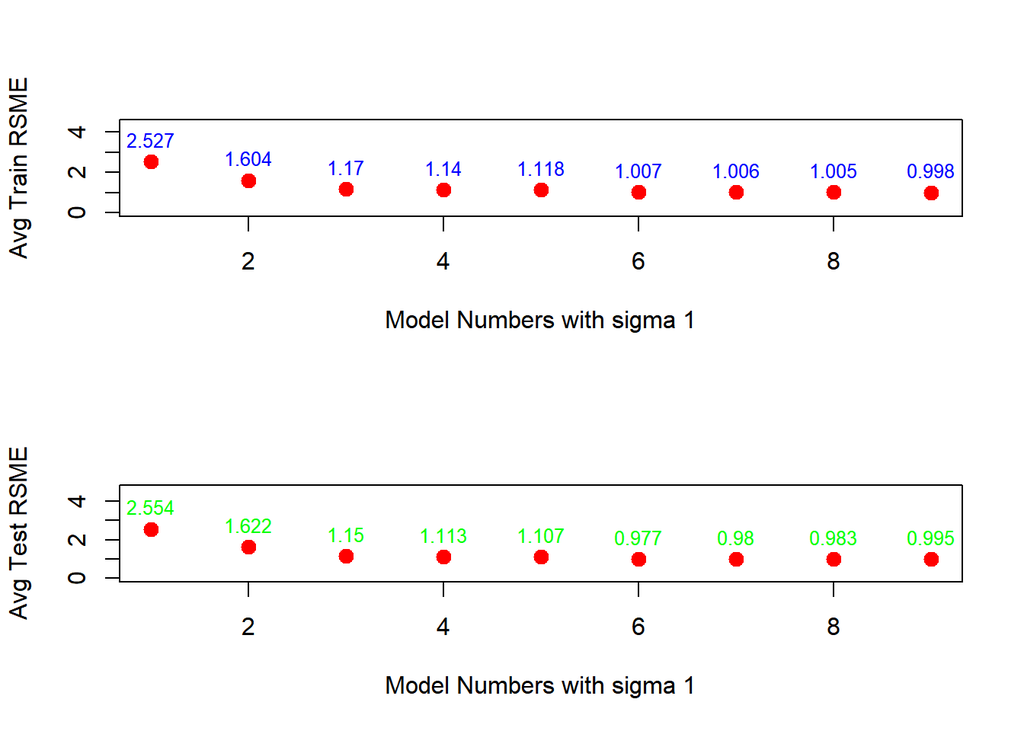

```r
train_max = max(avg_rmse_train)
test_max = max(avg_rmse_tst)

par(mfrow=c(2,1))
model_num = c(1:9)
plot(avg_rmse_train[1, ] ~ model_num, xlim = c(1,9), ylim = c(0, train_max), pch = 20, cex = 2, col="red", xlab = "Model Numbers with sigma 1", ylab = "Avg Train RSME")
text(avg_rmse_train[1, ] ~ model_num, labels = round(avg_rmse_train[1, ], 3), pos = 3, cex = .8, col="blue")

plot(avg_rmse_tst[1, ] ~ model_num, xlim = c(1,9), ylim = c(0, test_max), pch = 20, cex = 2, col="red", xlab = "Model Numbers with sigma 1", ylab = "Avg Test RSME")
text(avg_rmse_tst[1, ] ~ model_num, labels = round(avg_rmse_tst[1, ], 3), pos = 3, cex = .8, col="green")
```

With sigma value of 2

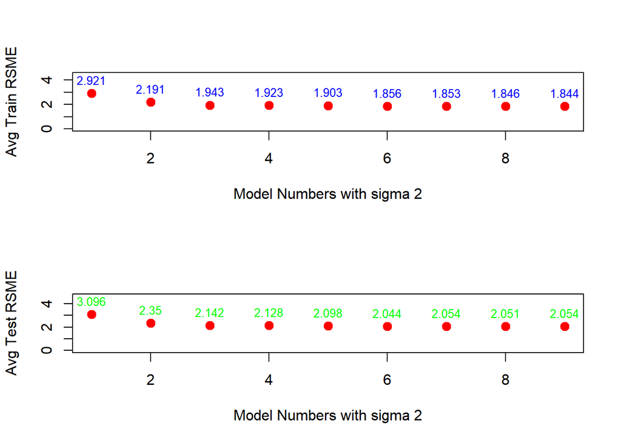

```r
train_max = max(avg_rmse_train)
test_max = max(avg_rmse_tst)

par(mfrow=c(2,1))
model_num = c(1:9)
plot(avg_rmse_train[2, ] ~ model_num, xlim = c(1,9), ylim = c(0, train_max), pch = 20, cex = 2, col="red", xlab = "Model Numbers with sigma 2", ylab = "Avg Train RSME")
text(avg_rmse_train[2, ] ~ model_num, labels = round(avg_rmse_train[2, ], 3), pos = 3, cex = .8, col="blue")

plot(avg_rmse_tst[2, ] ~ model_num, xlim = c(1,9), ylim = c(0, test_max), pch = 20, cex = 2, col="red", xlab = "Model Numbers with sigma 2", ylab = "Avg Test RSME")
text(avg_rmse_tst[2, ] ~ model_num, labels = round(avg_rmse_tst[2, ], 3), pos = 3, cex = .8, col="green")
```

With sigma value of 4

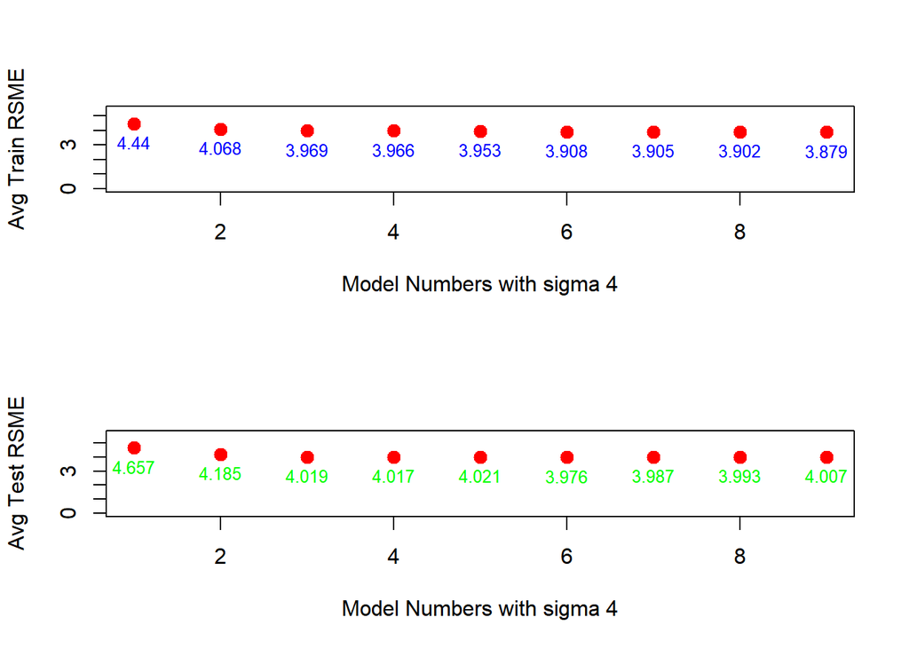

```r
train_max = max(avg_rmse_train)
test_max = max(avg_rmse_tst)

par(mfrow=c(2,1))
model_num = c(1:9)
plot(avg_rmse_train[3, ] ~ model_num, xlim = c(1,9), ylim = c(0, train_max+1), pch = 20, cex = 2, col="red", xlab = "Model Numbers with sigma 4", ylab = "Avg Train RSME")
text(avg_rmse_train[3, ] ~ model_num, labels = round(avg_rmse_train[3, ], 3), pos = 1, cex = .8, col="blue")

plot(avg_rmse_tst[3, ] ~ model_num, xlim = c(1,9), ylim = c(0, test_max+1), pch = 20, cex = 2, col="red", xlab = "Model Numbers with sigma 4", ylab = "Avg Test RSME")
text(avg_rmse_tst[3, ] ~ model_num, labels = round(avg_rmse_tst[3, ], 3), pos = 1, cex = .8, col="green")
```